# Inside the Algorithm: A Visual Story of Social Media Ads

Every time you open TikTok, Instagram, or YouTube, an algorithm decides which ads to show you. Over one session on **1 April 2026**, I logged every ad I encountered — recording the platform, category, duration, skippability, and how relevant it felt. This is what I found.

40Ads logged

3Platforms

7Ad categories

## TikTok dominates my ad feed

Of the 40 ads logged, **30 came from TikTok** — that’s 75% of all ads. Instagram and YouTube each contributed just a handful. This reflects how much more time I spend scrolling TikTok compared to other platforms, but also how aggressively TikTok serves ads relative to content.

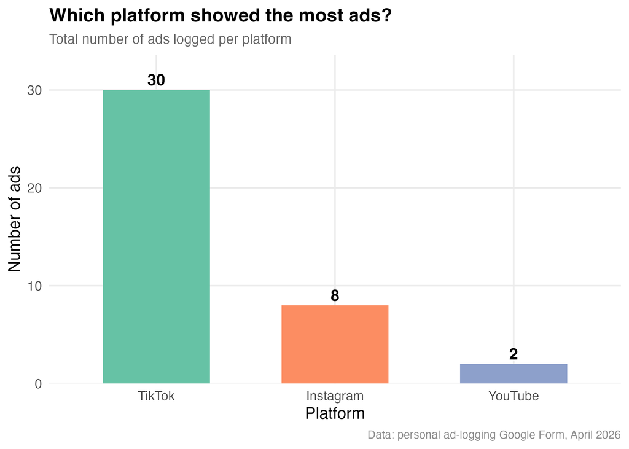

Figure 1: Total ads logged per platform. TikTok accounted for 75% of all ads observed.

**Key takeaway:** TikTok’s ad frequency is higher than other apps, due to the higher frequency of videos shown to the user so therefore, given the same percentage of videos being ads, the user will see more ads.

## Health & fitness ads feel the most relevant — by far

Not all ad categories land equally. Health & fitness ads scored a mean relevance of **4.2 out of 5**, far ahead of every other category. Tech/apps came second at 2.1, while fashion/beauty scored just 1 — the lowest possible. This suggests the algorithm has learned my interests well.

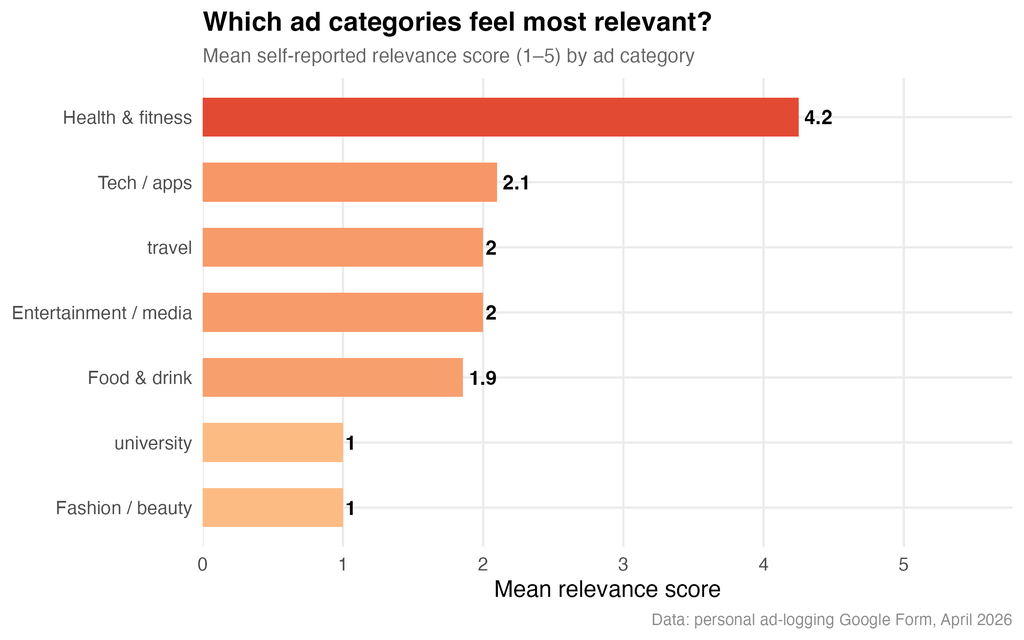

Figure 2: Mean self-reported relevance score (1–5) by ad category. Health & fitness stands out as the most personally relevant category.

**Key takeaway:** The algorithm seems to have a strong signal on health & fitness interest, but doesn’t serve relevant fashion or food content due to me not interacting those posts. The division of ad showings seem to represent my interests well showing that the ad algorithm has learnt my interests and is showing me more ads on topics I am interested in.

Does the length of an ad affect how relevant it feels? Looking at mean relevance by duration, **60-second ads** achieved the highest average score (~3.25), followed by a dip at N/A. Interestingly, 0-second ads (instant-skip formats on Instagram) rated low, which is likely because when shown an instant skip ad I do not bother to actually process the content of the ad and therefore likely miss the product it is selling.

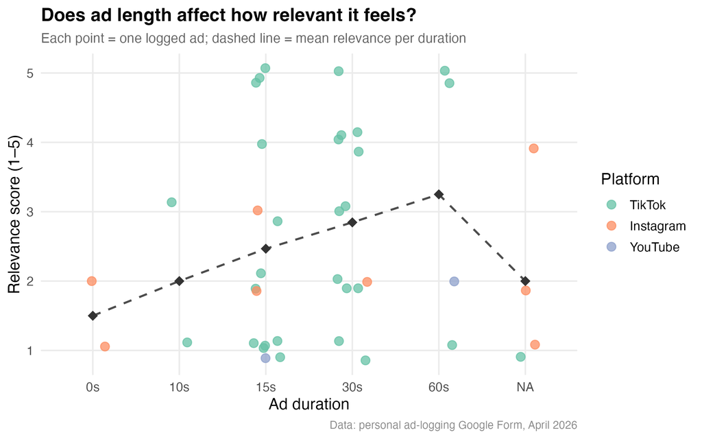

**Key takeaway:** 60-second ads appear to be the optimal length.

## Ad frequency ramped up mid-session

Logging ads across the session revealed an interesting temporal pattern: ad frequency was relatively low at the start (7:07–7:09 pm), then **surged between 7:11 and 7:12 pm**, with 5 ads logged in a single minute. This could reflect the algorithm “warming up” as it gathers more behavioural data from the session, or simply a cluster of ad breaks in TikTok’s feed structure.

[figure not shown]

**Key takeaway:** Ad density isn’t constant — it appears to increase as a session progresses, possibly as the algorithm gathers more engagement data.

Data collected via personal observational logging on 1 April 2026 · STATS 220 Project 4 · Data source: Google Form (Google Sheets published CSV)